# Oregon 2020 Wildfire Season: Air Quality

Astrid Sanna

2021-01-14

When we think of wildfires in the United States, the consequences of their destructive force and the need for preventive emergency plans are the first things that come to mind, especially if we live in high-risk regions such as the Pacific North West (PNW). Indeed, Oregon was one of the states of the PNW most affected by this past wildfire season, and we can all vividly recall the news about people forced to leave their homes for good in order to escape the incoming wildfires. The 2020 [wildfire season](https://en.wikipedia.org/wiki/2020_Oregon_wildfires) was the worst of Oregon’s history, with 90% of the wildfires caused by people and further exacerbated by remarkably strong winds and dry weather. However, what was destroyed and lost is just a part of the tragedy. This article is meant to inform about the aftermath of wildfire events in Oregon, giving a closer look at the [air quality](https://www.oregon.gov/oha/PH/HEALTHYENVIRONMENTS/TRACKINGASSESSMENT/ENVIRONMENTALPUBLICHEALTHTRACKING/Pages/EPHT-Indicator-Outdoor-Air.aspx) index (AQI) during the last Fall season (09/22/2020 – 12/21/2020) with a focus on small particulates (PM2.5) generated by wildfire smoke – which can cause severe respiratory issues.

According to the [AirNow](https://www.airnow.gov/) ambient monitoring data represented in the map below, many monitoring sites recorded days with unhealthy and USG (Unhealthy for Sensitive Groups) levels of PM2.5.

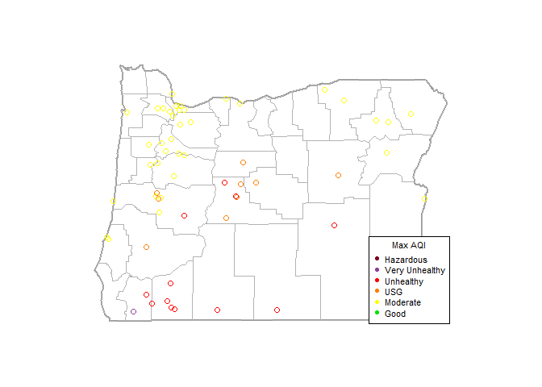

(**Note** that this is not the regulatory midnight-to-midnight AQI but a continuous 24-hr rolling mean.)

More details about each monitoring site including specific PM2.5 levels can be explored by navigating the dynamic map below.

[interactive chart not shown]

As you notice, Josephine and Jackson counties were among those with the worst air-quality days, and the following time series plot shows which period in the Fall season was the worst. Accounting for the missing data of the entire month of November, through visual examination we can agree that the last week of September and roughly the first two weeks of October were the most alarming (09/22/2020 – 10/12/2020).

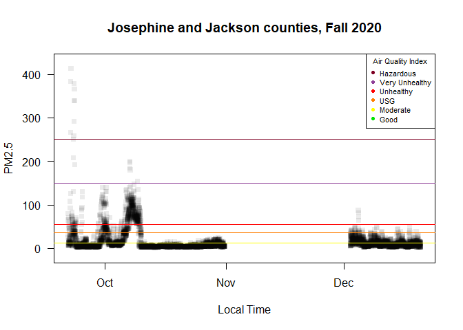

Further analysis of some of the monitoring sites with the highest midnight-to-midnight AQI levels reveals us that the Cave Junction Forest Service site was the one with the greatest number of days with unhealthy levels of PM2.5 during the time period (see graphic below). The site was also the worst one for chronic smoke (AQI greater or equal to 55.5 PM2.5) followed by the Provolt - Seed Orchard and Medford Welch & Jackson sites.

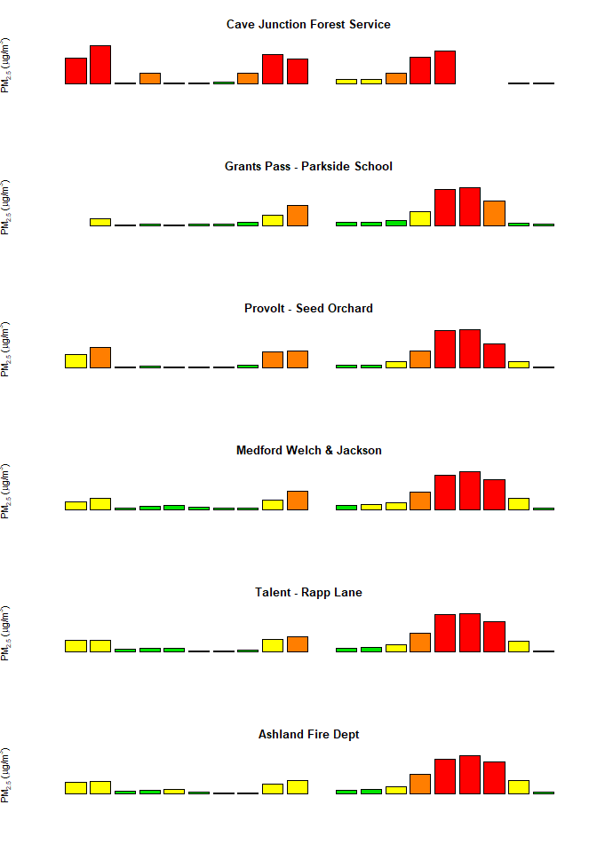

Started in California, the wildfire that burned in Josephine county was one of the largest of the season as illustrated in the table and map below. Moreover, the Lionshead and The Beachie Creek fires were two of the three wildfires that then merged into the 402,274-acre [Santiam fire](https://en.wikipedia.org/wiki/Santiam_Fire), which was finally contained in December.

Oregon Largest Wildfires

| Counties | Fire name | Acres | Ignition date |
| --- | --- | --- | --- |
| Jefferson, Linn, Marion, Wasco | Lionshead | 204,469 | August 16 |
| Clackamas, Linn, Marion | Beachie Creek | 193,573 | August 16 |
| Lane, Linn | Holiday Farm | 173,393 | September 7 |
| Josephine | Slater | 157,220 | September 8 |
| Clackamas | Riverside | 138,054 | September 8 |
| Douglas | Archie Creek | 131,542 | September 8 |

[figure not shown]

From this map we can see that Josephine and Jackson counties were scorched by three fires. Based on further analysis the six monitoring sites in their proximity were those with the worst AQI levels in the entire state during Fall. Additional investigation on wind direction and force is needed to define to what degree the other large fires could have affected Josephine and Jackson counties air quality.